# Sport Vouchers Program Analysis

The goal of this Portfolio task is to explore data from the Federal Government Sport Vouchers program - this is a program that provides up to two $100 vouchers for kids to participate in organised sport. Here's the [NSW Active Kids page](https://www.service.nsw.gov.au/transaction/apply-active-kids-voucher), there are similar schemes in other states - this data is from South Australia.

This is an exercise in exploring data and communicating the insights you can gain from it. The source data comes from the `data.gov.au` website and provides details of all Sport Vouchers that have been redeemed since February in SA 2015 as part of the Sport Voucher program: [Sports Vouchers Data](https://data.gov.au/dataset/ds-sa-14daba50-04ff-46c6-8468-9fa593b9f100/details). This download is provided for you as `sportsvouchersclaimed.csv`.

To augment this data you can also make use of [ABS SEIFA data by LGA](http://stat.data.abs.gov.au/Index.aspx?DataSetCode=ABS_SEIFA_LGA#) which shows a few measures of Socioeconomic Advantage and Disadvantage for every Local Government Area. This data is provided for you as `ABS_SEIFA_LGA.csv`. This could enable you to answer questions about whether the voucher program is used equally by parents in low, middle and high socioeconomic areas. You might be interested in this if you were concerned that this kind of program might just benifit parents who are already advantaged (they might already be paying for sport so this program wouldn't be helping much).

Questions:

- Describe the distribution of vouchers by: LGA, Sport - which regions/sports stand out?
- Are some sports more popular in different parts of the state?
- Are any LGA's over/under represented in their use of vouchers?
- Is there a relationship between any of the SEIFA measures and voucher use in an LGA?

A challenge in this task is to display a useful summary of the data given that there are a large number of LGAs and sports involved. Try to avoid long lists and large tables. Think about what plots and tables communicate the main points of your findings.

## 2.1 Load Libraries and Import Data

```python
import pandas as pd
import numpy as np
import matplotlib.pyplot as plt
import seaborn as sns
import folium
import geopandas as gpd
%matplotlib inline
```

```python
# read the sports vouchers data
sa_vouchers = pd.read_csv("files/sportsvouchersclaimed.csv")
sa_vouchers.head()
```

|  | Participant_ID | Participant_Suburb | Club_Previous_Member | Participant_ATSI_Indicator | Participant_CALD_Indicator | Participant_Sex | Voucher_Value | Club_Name | Voucher_Sport | Participant_LGA | Participant_Electorate | Voucher_Completion_Date | Voucher_Claim_Year |
| --- | --- | --- | --- | --- | --- | --- | --- | --- | --- | --- | --- | --- | --- |
| 0 | 1000002 | ABERFOYLE PARK | Registered Previously | Not ATSI | Not CALD | Male | 50 | Flagstaff Hill Football Club | Australian Rules | ONKAPARINGA | FISHER | 26/6/15 1:19 | 2015 |
| 1 | 1000002 | ABERFOYLE PARK | Registered Previously | Not ATSI | Not CALD | Male | 50 | Flagstaff Hill Football Club | Australian Rules | ONKAPARINGA | FISHER | 29/6/16 23:55 | 2016 |
| 2 | 1000004 | ABERFOYLE PARK | Not Registered Previously | Not ATSI | Not CALD | Female | 50 | Hub Gymnastics Club | Gymnastics | ONKAPARINGA | FISHER | 21/4/16 3:37 | 2016 |
| 3 | 1000004 | ABERFOYLE PARK | Registered Previously | Not ATSI | Not CALD | Female | 50 | Hub Gymnastics Club | Gymnastics | ONKAPARINGA | FISHER | 30/3/17 0:47 | 2017 |
| 4 | 1000005 | ABERFOYLE PARK | Registered Previously | Not ATSI | Not CALD | Female | 50 | Blackwood Community Recreation Association | Gymnastics | ONKAPARINGA | FISHER | 20/7/15 2:50 | 2015 |

The SEIFA data includes row for each Local Government Area (LGA) but the names of the LGAs have a letter or letters in brackets after the name. To allow us to match this up with the voucher data we remove this and convert to uppercase.

For each LGA the data includes a number of measures all of which could be useful in your exploration.

```python
# read the SEIFA data, create an LGA column by removing the letters in brackets and converting to uppercase
seifa = pd.read_csv('files/ABS_SEIFA_LGA.csv')
lga = seifa["Local Government Areas - 2011"].str.replace(' \([ACSRCDMT]+\)', '').str.upper()
seifa['LGA'] = lga
seifa.head()
```

|  | LGA_2011 | Local Government Areas - 2011 | INDEX_TYPE | Index Type | MEASURE | Measure | Value | LGA |
| --- | --- | --- | --- | --- | --- | --- | --- | --- |
| 0 | 10050 | Albury (C) | IRSAD | Index of Relative Socio-economic Advantage and... | SCORE | Score | 967 | ALBURY |
| 1 | 10050 | Albury (C) | IRSAD | Index of Relative Socio-economic Advantage and... | MINS | Minimum score for SA1s in area | 628 | ALBURY |
| 2 | 10050 | Albury (C) | IRSAD | Index of Relative Socio-economic Advantage and... | MAXS | Maximum score for SA1s in area | 1169 | ALBURY |
| 3 | 10050 | Albury (C) | IRSAD | Index of Relative Socio-economic Advantage and... | URP | Usual resident population | 47851 | ALBURY |
| 4 | 10110 | Armidale Dumaresq (A) | IRSAD | Index of Relative Socio-economic Advantage and... | SCORE | Score | 985 | ARMIDALE DUMARESQ |

Since there are many rows per LGA we need to use `pivot_table` to create a new data frame with one row per LGA. Here is an example of doing this to create a table with the different SCORE measures and the population (URP) field.

```python
LGA_scores = seifa[seifa.MEASURE == 'SCORE'].pivot_table(index="LGA", columns=["INDEX_TYPE"], values="Value")
LGA_scores.head()
LGA_pop = seifa[seifa.MEASURE == 'URP'].pivot_table(index="LGA", columns=["INDEX_TYPE"], values="Value")
LGA_scores['Population'] = LGA_pop.IEO
LGA_scores.head()
```

| INDEX_TYPE LGA | IEO | IER | IRSAD | IRSD | Population |
| --- | --- | --- | --- | --- | --- |
| ADELAIDE | 874.0 | 874.0 | 1036.0 | 1013.0 | 19606.0 |
| ADELAIDE HILLS | 1083.0 | 1083.0 | 1077.0 | 1081.0 | 38601.0 |
| ALBANY | 999.0 | 999.0 | 977.0 | 987.0 | 33614.0 |
| ALBURY | 964.0 | 964.0 | 967.0 | 979.0 | 47851.0 |
| ALEXANDRINA | 1000.0 | 1000.0 | 969.0 | 987.0 | 23693.0 |

This data frame can then be joined with the vouchers data frame to create one master data frame containing both the voucher data and the SEIFA measures.

```python
sa_vouchers_scores = sa_vouchers.join(LGA_scores, on='Participant_LGA')
sa_vouchers_scores.head()
```

|  | Participant_ID | Participant_Suburb | Club_Previous_Member | Participant_ATSI_Indicator | Participant_CALD_Indicator | Participant_Sex | Voucher_Value | Club_Name | Voucher_Sport | Participant_LGA | Participant_Electorate | Voucher_Completion_Date | Voucher_Claim_Year | IEO | IER | IRSAD | IRSD | Population |
| --- | --- | --- | --- | --- | --- | --- | --- | --- | --- | --- | --- | --- | --- | --- | --- | --- | --- | --- |
| 0 | 1000002 | ABERFOYLE PARK | Registered Previously | Not ATSI | Not CALD | Male | 50 | Flagstaff Hill Football Club | Australian Rules | ONKAPARINGA | FISHER | 26/6/15 1:19 | 2015 | 996.0 | 996.0 | 975.0 | 993.0 | 159517.0 |
| 1 | 1000002 | ABERFOYLE PARK | Registered Previously | Not ATSI | Not CALD | Male | 50 | Flagstaff Hill Football Club | Australian Rules | ONKAPARINGA | FISHER | 29/6/16 23:55 | 2016 | 996.0 | 996.0 | 975.0 | 993.0 | 159517.0 |
| 2 | 1000004 | ABERFOYLE PARK | Not Registered Previously | Not ATSI | Not CALD | Female | 50 | Hub Gymnastics Club | Gymnastics | ONKAPARINGA | FISHER | 21/4/16 3:37 | 2016 | 996.0 | 996.0 | 975.0 | 993.0 | 159517.0 |
| 3 | 1000004 | ABERFOYLE PARK | Registered Previously | Not ATSI | Not CALD | Female | 50 | Hub Gymnastics Club | Gymnastics | ONKAPARINGA | FISHER | 30/3/17 0:47 | 2017 | 996.0 | 996.0 | 975.0 | 993.0 | 159517.0 |
| 4 | 1000005 | ABERFOYLE PARK | Registered Previously | Not ATSI | Not CALD | Female | 50 | Blackwood Community Recreation Association | Gymnastics | ONKAPARINGA | FISHER | 20/7/15 2:50 | 2015 | 996.0 | 996.0 | 975.0 | 993.0 | 159517.0 |

## 2.2 Cleaning Data

```python
sa_vouchers_scores.info()
```

```
<class 'pandas.core.frame.DataFrame'>
RangeIndex: 127526 entries, 0 to 127525
Data columns (total 18 columns):
 #   Column                      Non-Null Count   Dtype
---  ------                      --------------   -----
 0   Participant_ID              127526 non-null  int64
 1   Participant_Suburb          127526 non-null  object
 2   Club_Previous_Member        127526 non-null  object
 3   Participant_ATSI_Indicator  127526 non-null  object
 4   Participant_CALD_Indicator  127526 non-null  object
 5   Participant_Sex             127526 non-null  object
 6   Voucher_Value               127526 non-null  int64
 7   Club_Name                   127526 non-null  object
 8   Voucher_Sport               127526 non-null  object
 9   Participant_LGA             127526 non-null  object
 10  Participant_Electorate      127526 non-null  object
 11  Voucher_Completion_Date     125446 non-null  object
 12  Voucher_Claim_Year          127526 non-null  int64
 13  IEO                         118066 non-null  float64
 14  IER                         118066 non-null  float64
 15  IRSAD                       118066 non-null  float64
 16  IRSD                        118066 non-null  float64
 17  Population                  118066 non-null  float64
dtypes: float64(5), int64(3), object(10)
memory usage: 17.5+ MB
```

```python
sa_vouchers_scores.isnull().sum()
```

```
Participant_ID                   0
Participant_Suburb               0
Club_Previous_Member             0
Participant_ATSI_Indicator       0
Participant_CALD_Indicator       0
Participant_Sex                  0
Voucher_Value                    0
Club_Name                        0
Voucher_Sport                    0
Participant_LGA                  0
Participant_Electorate           0
Voucher_Completion_Date       2080
Voucher_Claim_Year               0
IEO                           9460
IER                           9460
IRSAD                         9460
IRSD                          9460
Population                    9460
dtype: int64
```

### **Data Cleaning**

The 9460 null values were identified within the "sa_voushers_scores" pivot table under the SEIFA table attributes. This was a result of 8835 tuples with mismatching LGA names between the SEIFA and SA Voucher data tables. Also 625 tuples had "NO LGA" listed.

The following steps were taken to clean the data:

1. Of the 625 "NO LGA" tuples, 30 of the tuples contained data , such as "Participant_Suburb, from which the LGA could be dervived. As the number was so small all tuples with "NO LGA" in the "Participant_LGA" field were deleted.
2. The Adelaide Plains LGA changed its name from Mallala LGA in 2016. The SEIFA data reported all data under Mallala LGA. The SEIFA table was updated by changing "MALLALA" to "ADELAIDE PLAINS". This rectified 899 errors.
3. "BERRI BARMERA" was "BERRI AND BARMERA" in the SEIFA data. The name was changed in the SEIFA data and rectified 1486 errors.
4. In the SEIFA data "LIGHT" was followed by (RegC). The (RegC) was removed which rectified 2066 errors.
5. "NARACOORTE LUCINDALE" was "NARACOORTE AND LUCINDALE" in the SEIFA data. The name was changed in the SEIFA data and rectified 1097 errors.
6. "NORWOOD PAYNEHAM AND ST PETERS" was "NORWOOD PAYNEHAM ST PETERS" in the SEIFA data. The name was changed in the SEIFA data and rectified 1352 errors.
7. "PORT PERIE" WAS "PORT PERIE CITY AND DISTS" in the SEIFA data. The name was changed in the SEIFA data and rectified 1935 errors.
8. Kingston is a district council in South Australia and a city in Victoria. The "KINGSTON (C)" (Victorian city) was dropped from the SEIFA Data. This resolved the created in the calculation of the total population.

```python
sa_vouchers = pd.read_csv("files/sportsvouchersclaimed.csv")
#removing tupples with no LGA
sa_vouchers = sa_vouchers[sa_vouchers['Participant_LGA']!='NO LGA']
sa_vouchers.head()
```

|  | Participant_ID | Participant_Suburb | Club_Previous_Member | Participant_ATSI_Indicator | Participant_CALD_Indicator | Participant_Sex | Voucher_Value | Club_Name | Voucher_Sport | Participant_LGA | Participant_Electorate | Voucher_Completion_Date | Voucher_Claim_Year |
| --- | --- | --- | --- | --- | --- | --- | --- | --- | --- | --- | --- | --- | --- |
| 0 | 1000002 | ABERFOYLE PARK | Registered Previously | Not ATSI | Not CALD | Male | 50 | Flagstaff Hill Football Club | Australian Rules | ONKAPARINGA | FISHER | 26/6/15 1:19 | 2015 |
| 1 | 1000002 | ABERFOYLE PARK | Registered Previously | Not ATSI | Not CALD | Male | 50 | Flagstaff Hill Football Club | Australian Rules | ONKAPARINGA | FISHER | 29/6/16 23:55 | 2016 |
| 2 | 1000004 | ABERFOYLE PARK | Not Registered Previously | Not ATSI | Not CALD | Female | 50 | Hub Gymnastics Club | Gymnastics | ONKAPARINGA | FISHER | 21/4/16 3:37 | 2016 |
| 3 | 1000004 | ABERFOYLE PARK | Registered Previously | Not ATSI | Not CALD | Female | 50 | Hub Gymnastics Club | Gymnastics | ONKAPARINGA | FISHER | 30/3/17 0:47 | 2017 |
| 4 | 1000005 | ABERFOYLE PARK | Registered Previously | Not ATSI | Not CALD | Female | 50 | Blackwood Community Recreation Association | Gymnastics | ONKAPARINGA | FISHER | 20/7/15 2:50 | 2015 |

```python
#addressing mismatching labels
seifa = pd.read_csv('files/ABS_SEIFA_LGA.csv')
seifa = seifa[seifa["Local Government Areas - 2011"] != 'Kingston (C)']
lga = seifa["Local Government Areas - 2011"].str.replace(' \([ACSRCDMTRegC]+\)', '').str.upper()
seifa['LGA'] = lga
seifa['LGA'].loc[seifa.LGA == 'BERRI AND BARMERA'] = 'BERRI BARMERA'
seifa['LGA'].loc[seifa.LGA == 'MALLALA'] = 'ADELAIDE PLAINS'
seifa['LGA'].loc[seifa.LGA == 'NARACOORTE AND LUCINDALE'] = 'NARACOORTE LUCINDALE'
seifa['LGA'].loc[seifa.LGA == 'PORT PIRIE CITY AND DISTS'] = 'PORT PIRIE'
seifa['LGA'].loc[seifa.LGA == 'NORWOOD PAYNEHAM ST PETERS'] = 'NORWOOD PAYNEHAM AND ST PETERS'
seifa.head()
```

|  | LGA_2011 | Local Government Areas - 2011 | INDEX_TYPE | Index Type | MEASURE | Measure | Value | LGA |
| --- | --- | --- | --- | --- | --- | --- | --- | --- |
| 0 | 10050 | Albury (C) | IRSAD | Index of Relative Socio-economic Advantage and... | SCORE | Score | 967 | ALBURY |
| 1 | 10050 | Albury (C) | IRSAD | Index of Relative Socio-economic Advantage and... | MINS | Minimum score for SA1s in area | 628 | ALBURY |
| 2 | 10050 | Albury (C) | IRSAD | Index of Relative Socio-economic Advantage and... | MAXS | Maximum score for SA1s in area | 1169 | ALBURY |
| 3 | 10050 | Albury (C) | IRSAD | Index of Relative Socio-economic Advantage and... | URP | Usual resident population | 47851 | ALBURY |
| 4 | 10110 | Armidale Dumaresq (A) | IRSAD | Index of Relative Socio-economic Advantage and... | SCORE | Score | 985 | ARMIDALE DUMARESQ |

```python
LGA_scores = seifa[seifa.MEASURE == 'SCORE'].pivot_table(index="LGA", columns=["INDEX_TYPE"], values="Value")
LGA_pop = seifa[seifa.MEASURE == 'URP'].pivot_table(index="LGA", columns=["INDEX_TYPE"], values="Value")
LGA_scores['Population'] = LGA_pop.IEO
LGA_scores.head()
```

| INDEX_TYPE LGA | IEO | IER | IRSAD | IRSD | Population |
| --- | --- | --- | --- | --- | --- |
| ADELAIDE | 874.0 | 874.0 | 1036.0 | 1013.0 | 19606.0 |
| ADELAIDE HILLS | 1083.0 | 1083.0 | 1077.0 | 1081.0 | 38601.0 |
| ADELAIDE PLAINS | 1035.0 | 1035.0 | 962.0 | 980.0 | 8333.0 |
| ALBANY | 999.0 | 999.0 | 977.0 | 987.0 | 33614.0 |
| ALBURY | 964.0 | 964.0 | 967.0 | 979.0 | 47851.0 |

```python
#final clean data set
sa_vouchers_scores = sa_vouchers.join(LGA_scores, on='Participant_LGA')
sa_vouchers_scores.head()
```

|  | Participant_ID | Participant_Suburb | Club_Previous_Member | Participant_ATSI_Indicator | Participant_CALD_Indicator | Participant_Sex | Voucher_Value | Club_Name | Voucher_Sport | Participant_LGA | Participant_Electorate | Voucher_Completion_Date | Voucher_Claim_Year | IEO | IER | IRSAD | IRSD | Population |
| --- | --- | --- | --- | --- | --- | --- | --- | --- | --- | --- | --- | --- | --- | --- | --- | --- | --- | --- |
| 0 | 1000002 | ABERFOYLE PARK | Registered Previously | Not ATSI | Not CALD | Male | 50 | Flagstaff Hill Football Club | Australian Rules | ONKAPARINGA | FISHER | 26/6/15 1:19 | 2015 | 996.0 | 996.0 | 975.0 | 993.0 | 159517.0 |
| 1 | 1000002 | ABERFOYLE PARK | Registered Previously | Not ATSI | Not CALD | Male | 50 | Flagstaff Hill Football Club | Australian Rules | ONKAPARINGA | FISHER | 29/6/16 23:55 | 2016 | 996.0 | 996.0 | 975.0 | 993.0 | 159517.0 |
| 2 | 1000004 | ABERFOYLE PARK | Not Registered Previously | Not ATSI | Not CALD | Female | 50 | Hub Gymnastics Club | Gymnastics | ONKAPARINGA | FISHER | 21/4/16 3:37 | 2016 | 996.0 | 996.0 | 975.0 | 993.0 | 159517.0 |
| 3 | 1000004 | ABERFOYLE PARK | Registered Previously | Not ATSI | Not CALD | Female | 50 | Hub Gymnastics Club | Gymnastics | ONKAPARINGA | FISHER | 30/3/17 0:47 | 2017 | 996.0 | 996.0 | 975.0 | 993.0 | 159517.0 |
| 4 | 1000005 | ABERFOYLE PARK | Registered Previously | Not ATSI | Not CALD | Female | 50 | Blackwood Community Recreation Association | Gymnastics | ONKAPARINGA | FISHER | 20/7/15 2:50 | 2015 | 996.0 | 996.0 | 975.0 | 993.0 | 159517.0 |

```python
sa_vouchers_scores.isnull().sum()
```

```
Participant_ID                   0
Participant_Suburb               0
Club_Previous_Member             0
Participant_ATSI_Indicator       0
Participant_CALD_Indicator       0
Participant_Sex                  0
Voucher_Value                    0
Club_Name                        0
Voucher_Sport                    0
Participant_LGA                  0
Participant_Electorate           0
Voucher_Completion_Date       2054
Voucher_Claim_Year               0
IEO                              0
IER                              0
IRSAD                            0
IRSD                             0
Population                       0
dtype: int64
```

## 2.3 Data Acronyms and Indexes

*Sports Vouchers Data*

[Metadata](https://data.gov.au/dataset/ds-sa-14daba50-04ff-46c6-8468-9fa593b9f100/distribution/dist-sa-f5654114-6400-4568-aeba-4a36419134da/details?q=)

**Club_Previous_Member**: Categorises the participant as new (not registered) or returning (registered) participant of the activity provider

**Participant_ATSI_Indicator**: Categorises the participant as identifying with aboriginal or Torres Strait Island heritage (ATSI), or not (Not ATSI)

**Participant_CALD_Indicator**: Categorises the participant as identifying with a non-Australian cultural background (CALD) or not (Not CALD)

**Voucher_Value**: Value of the voucher redeemed by the participant (Maximum $50 AUD per annum)

*SEIFA data by LGA*

[SEIFA Summary](https://www.abs.gov.au/ausstats/abs@.nsf/Lookup/2033.0.55.001main+features42011)

The four SEIFA indexes include:

[Index of Education and Occupation (IEO)](https://www.abs.gov.au/ausstats/abs@.nsf/Lookup/2033.0.55.001main+features100072011): an index which reflects the educational and occupational levels of communities. Low score indicates lower education and occupation status of people in the area. High score indicates higher education and occupation status of people in the area.

[Index of Economic Resources (IER)](https://www.abs.gov.au/ausstats/abs@.nsf/Lookup/2033.0.55.001main+features100062011): an index which focuses on the relative aspects of socio-economic adnavtage and disadvantage by summarising income and wealth related variables. Low score indicates a relative lack of access to economic resources. High score indicates relatively greater access to economic resources.

[Index of Relative Socio-Economic Advantage and Disadvantage (IRSAD)](https://www.abs.gov.au/ausstats/abs@.nsf/Lookup/2033.0.55.001main+features100042011): an index which summarises the economic andsocial conditions of people and households within an area. Low score indicates relatively greater disadvantage and a lack of advantage in general. high score indicates a relative lack of disadvantage and greater advantage in general.

[Index of Relative Socio-Economic Disadvantage (IRSD)](https://www.abs.gov.au/ausstats/abs@.nsf/Lookup/2033.0.55.001main+features100052011): an index which summarises the economic and social conditions of people and households within an area. low score indicates relatively greater disadvantage. high score indicates a relative lack of disadvantage.

## 2.4 Preliminary Investigation

```python
#data shape
sa_vouchers_scores.shape
```

```
(126901, 18)
```

```python
#descriptive statistics across LGA's
LGA_desc = pd.DataFrame(sa_vouchers_scores[['Participant_LGA', 'Voucher_Value', 'IER', 'IRSAD', 'IRSD', 'Population']])
LGA_desc = LGA_desc.drop_duplicates(subset=['Participant_LGA'], keep='first')
round(LGA_desc.describe(),2)
```

|  | Voucher_Value | IER | IRSAD | IRSD | Population |
| --- | --- | --- | --- | --- | --- |
| count | 68.00 | 68.00 | 68.00 | 68.00 | 68.00 |
| mean | 48.16 | 981.02 | 966.56 | 978.63 | 24046.68 |
| std | 7.22 | 45.27 | 56.24 | 55.32 | 34422.89 |
| min | 10.00 | 870.00 | 808.00 | 798.00 | 871.00 |
| 25% | 50.00 | 959.25 | 930.50 | 945.00 | 3330.75 |
| 50% | 50.00 | 981.50 | 967.00 | 982.50 | 9910.50 |
| 75% | 50.00 | 1009.25 | 994.25 | 1015.50 | 24083.25 |
| max | 50.00 | 1083.00 | 1090.00 | 1096.00 | 159517.00 |

```python
#Total population of South Australia
print(f'Total population of South Australia: {LGA_desc.Population.sum()}')
```

```
Total population of South Australia: 1635174.0
```

```python
print(f'Total number of vouchers redeemed: {sa_vouchers_scores.shape[0]}')
print(f'Total number of participating clubs: {len(set(sa_vouchers_scores.Club_Name))}')
print(f'Total number of participating sports: {len(set(sa_vouchers_scores.Voucher_Sport))}')
print(f'Total number of participating LGAs: {len(set(sa_vouchers_scores.Participant_LGA))}')
```

```
Total number of vouchers redeemed: 126901
Total number of participating clubs: 1162
Total number of participating sports: 50
Total number of participating LGAs: 68
```

## 2.5 Distribution of Vouchers

*Describe the distribution of vouchers by: LGA, Sport - which regions/sports stand out?*

### 2.5.1 Distribution by LGA

```python
#Top ten LGA's by number of vouchers claimed
lga_dist = sa_vouchers_scores['Participant_LGA'].value_counts().rename_axis('unique_values').to_frame('Vouchers_Claimed')
lga_dist.sort_values(by='Vouchers_Claimed', ascending=False)
lga_dist.head(10)
```

| unique_values | Vouchers_Claimed |
| --- | --- |
| ONKAPARINGA | 12782 |
| SALISBURY | 8169 |
| TEA TREE GULLY | 7219 |
| PLAYFORD | 6940 |
| CHARLES STURT | 6897 |
| PORT ADELAIDE ENFIELD | 6384 |
| MARION | 5291 |
| ADELAIDE HILLS | 4756 |
| MITCHAM | 4662 |
| MOUNT BARKER | 3469 |

```python
#Bottom ten LGA's by number of vouchers claimed
lga_dist.tail(10)
```

| unique_values | Vouchers_Claimed |
| --- | --- |
| ROXBY DOWNS | 234 |
| KIMBA | 232 |
| MOUNT REMARKABLE | 205 |
| ROBE | 167 |
| ELLISTON | 165 |
| FRANKLIN HARBOUR | 155 |
| ORROROO/CARRIETON | 137 |
| FLINDERS RANGES | 102 |
| PETERBOROUGH | 45 |
| COOBER PEDY | 39 |

```python
#descriptive statistics for LGA's
round(lga_dist.describe(),2)
```

|  | Vouchers_Claimed |
| --- | --- |
| count | 68.00 |
| mean | 1866.19 |
| std | 2360.31 |
| min | 39.00 |
| 25% | 339.75 |
| 50% | 1019.00 |
| 75% | 2227.75 |
| max | 12782.00 |

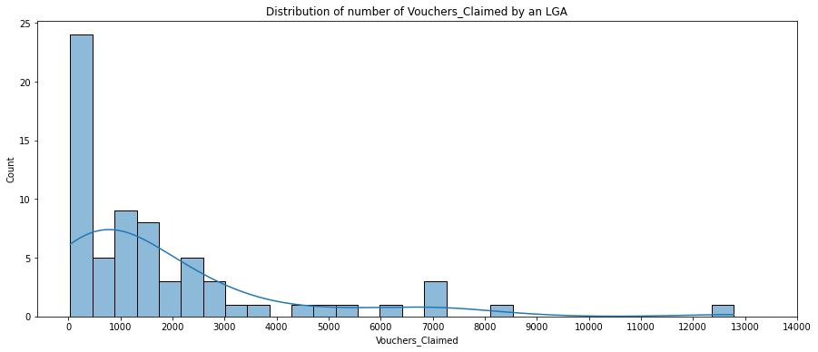

```python
plt.figure(figsize=(15,6))
ax = sns.histplot(data=lga_dist, x='Vouchers_Claimed', bins = 30, kde = True)
ax.set_title('Distribution of number of Vouchers_Claimed by an LGA')
plt.xticks(range(0,15000,1000))
plt.show()
```

The distribution of number of vouchers claimed is right skewed, with a small number of LGA's claiming a large number of vouchers. The majority of LGA's claim less then 1,200 vouchers each. The `ONKAPARINGA` LGA has claimed over 12,500. The `COOBER PEDY` LGA has claimed only 39.

```python
#import community geojson data for mapping LGA areas
sa_lga_geojson = gpd.read_file("files\LGA_GDA2020.geojson")
sa_lga_geojson.drop(columns=['lgatype', 'lga', 'shape_Length', 'shape_Area'], inplace=True)
sa_lga_geojson.sort_values('abbname')
sa_lga_geojson['abbname'].loc[sa_lga_geojson.abbname == 'COORONG'] =  'THE COORONG'
lga_drop = ['APY', 'MT', 'PUA', 'UIA RIVERLAND', 'UIA TORRENS ISLAND', 'UIA WHYALLA']
for i in lga_drop:
    sa_lga_geojson.drop(sa_lga_geojson.index[sa_lga_geojson.abbname == i], inplace=True)
sa_lga_geojson.head()
```

|  | abbname | geometry |
| --- | --- | --- |
| 0 | ADELAIDE | MULTIPOLYGON (((138.61916 -34.92526, 138.62178... |
| 1 | BURNSIDE | MULTIPOLYGON (((138.69662 -34.92009, 138.69746... |
| 2 | MOUNT GAMBIER | MULTIPOLYGON (((140.78651 -37.80198, 140.78662... |
| 3 | PORT ADELAIDE ENFIELD | MULTIPOLYGON (((138.51045 -34.79261, 138.50967... |
| 4 | PORT AUGUSTA | MULTIPOLYGON (((137.75403 -32.37753, 137.75448... |

```python
#creating map table
map_data = pd.merge(sa_lga_geojson,lga_dist,left_on='abbname', right_on='unique_values')
```

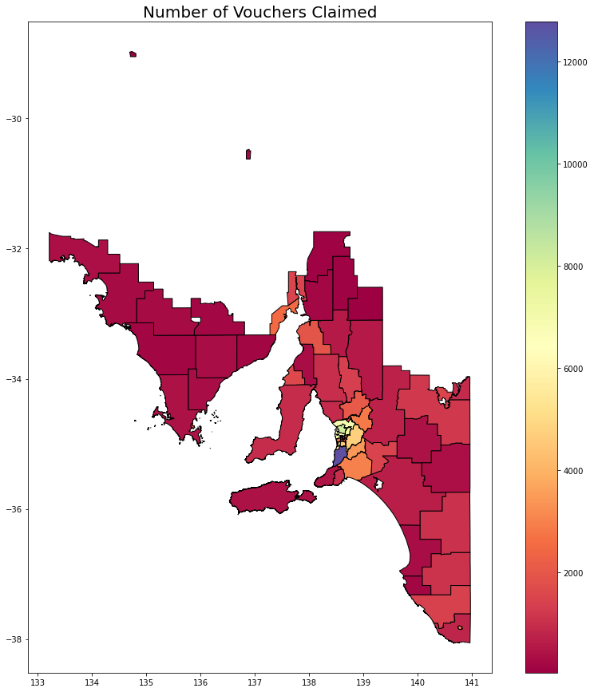

```python
#plotting map using geopandas
map_data.plot(column='Vouchers_Claimed', cmap='Spectral', edgecolor = 'k', legend = 'True', figsize=(15, 15))
plt.title('Number of Vouchers Claimed',fontsize=20)
plt.show()
```

NOTE: An interactive map was created and the code is available below. The code was not run as it made the file size to large to commit to github. Insights are based off the interactive map.

```python
#plotting voucher claimed data to interactive map (click on LGA to see Label and number of vouchers claimed)
mV = folium.Map(location=[-34.6, 134.85], zoom_start=6.5, tiles='CartoDB positron', zoom_control=False,scrollWheelZoom=False,dragging=False)
folium.Choropleth(
    geo_data=map_data,
    name="choropleth",
    data=map_data,
    columns=["abbname", "Vouchers_Claimed"],
    key_on="feature.properties.abbname",
    fill_color="Spectral",
    line_color = 'grey',
    line_weight = 2,
    fill_opacity=0.7,
    line_opacity=1,
    legend_name="Number of vouchers claimed",
).add_to(mV)

style_function = lambda x: {'fillColor': '#ffffff',
                            'color':'#000000',
                            'fillOpacity': 0.1,
                            'weight': 0.1}

highlight_function = lambda x: {'fillColor': '#000000',
                                'color':'#000000',
                                'fillOpacity': 0.50,
                                'weight': 0.1}

folium.features.GeoJson(
    map_data, name = 'LGA',
    popup=folium.features.GeoJsonPopup(fields=['abbname', 'Vouchers_Claimed']),
    style_function = style_function,
    highlight_function = highlight_function,
    ).add_to(mV)
folium.LayerControl().add_to(mV)
mV
```

As can be observed from the above map, LGA's in and around the South Australian capital of Adelaide claimed more vouchers then the surrounding rural LGA's. Interestingly, The Whyalla LGA has claimed significantly more vouchers then surrounding LGA's.

### 2.5.2 Distribution by Sport

```python
#Top 10 sports by number of vouchers claimed
sport_dist = sa_vouchers_scores['Voucher_Sport'].value_counts().rename_axis('unique_values').to_frame('Vouchers_Claimed')
sport_dist.sort_values(by='Vouchers_Claimed', ascending=False)
sport_dist.head(10)
```

| unique_values | Vouchers_Claimed |
| --- | --- |
| Australian Rules | 47051 |
| Netball | 23938 |
| Football (Soccer) | 15662 |
| Gymnastics | 9754 |
| Basketball | 5967 |
| Athletics | 4501 |
| Tennis | 3730 |
| Hockey | 3012 |
| Calisthenics | 2506 |
| Cricket | 1853 |

```python
#Bottom ten sports by number of vouchers claimed
sport_dist.tail(10)
```

| unique_values | Vouchers_Claimed |
| --- | --- |
| Wrestling | 19 |
| Pony Clubs | 17 |
| Surf Riding | 15 |
| Weightlifting | 4 |
| Badminton | 4 |
| Shooting | 4 |
| Paralympics | 3 |
| Kung Fu (Wu Shu) | 2 |
| Dancesport | 2 |
| Bowls | 1 |

```python
#descriptive statistics for sports
round(sport_dist.describe(),2)
```

|  | Vouchers_Claimed |
| --- | --- |
| count | 50.00 |
| mean | 2538.02 |
| std | 7693.69 |
| min | 1.00 |
| 25% | 25.00 |
| 50% | 125.50 |
| 75% | 891.25 |
| max | 47051.00 |

The average number of vouchers claimed by a sport was 2,538.02. The spread is very large.

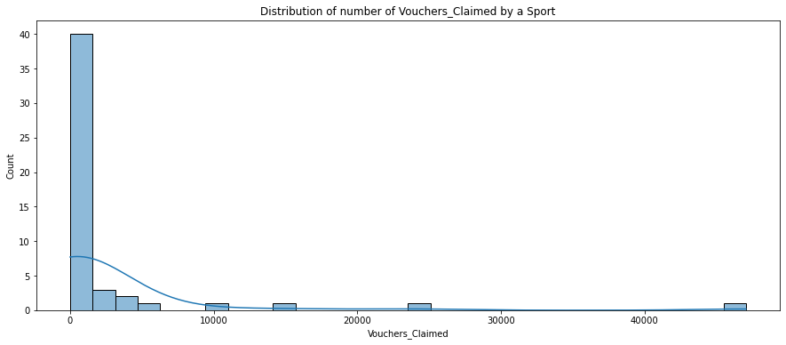

```python
plt.figure(figsize=(15,6))
ax = sns.histplot(data=sport_dist, x='Vouchers_Claimed', bins = 30, kde = True)
ax.set_title('Distribution of number of Vouchers_Claimed by a Sport')
plt.show()
```

The distribution was right skewed with a small number of sports claiming a significant proportion of the total vouchers. The overwhelming majority of the sports claimed less then 1,500 vouchers. `Bowls` claimed only a single voucher while `Australian Rules` claimed 47,051.

## 2.6 Popularity of Sport by LGA

*Are some sports more popular in different parts of the state?*

```python
#table showing the number of vouchers claimed by each sport and LGA
sport_x_lga = sa_vouchers_scores[['Voucher_Sport', 'Participant_LGA']]
sport_x_lga = sport_x_lga.groupby(['Participant_LGA', 'Voucher_Sport'], as_index=False).size()
sport_x_lga = sport_x_lga.pivot(index = 'Participant_LGA', columns = 'Voucher_Sport', values = 'size').fillna(0)
sport_x_lga.head()
```

| Voucher_Sport Participant_LGA | Archery | Athletics | Australian Rules | BMX | Badminton | Baseball | Basketball | Bowls | Calisthenics | Cricket | ... | Surf Riding | Swimming | Table Tennis | Taekwondo | Tennis | Touch | Volleyball | Water Polo | Weightlifting | Wrestling |
| --- | --- | --- | --- | --- | --- | --- | --- | --- | --- | --- | --- | --- | --- | --- | --- | --- | --- | --- | --- | --- | --- |
| ADELAIDE | 0.0 | 16.0 | 130.0 | 0.0 | 0.0 | 1.0 | 4.0 | 0.0 | 1.0 | 2.0 | ... | 0.0 | 0.0 | 0.0 | 11.0 | 4.0 | 0.0 | 0.0 | 0.0 | 0.0 | 0.0 |
| ADELAIDE HILLS | 3.0 | 204.0 | 1412.0 | 2.0 | 0.0 | 11.0 | 48.0 | 0.0 | 62.0 | 128.0 | ... | 0.0 | 18.0 | 3.0 | 44.0 | 257.0 | 2.0 | 1.0 | 1.0 | 0.0 | 0.0 |
| ADELAIDE PLAINS | 0.0 | 3.0 | 485.0 | 0.0 | 0.0 | 3.0 | 15.0 | 0.0 | 23.0 | 3.0 | ... | 0.0 | 3.0 | 0.0 | 0.0 | 13.0 | 0.0 | 0.0 | 0.0 | 0.0 | 0.0 |
| ALEXANDRINA | 9.0 | 62.0 | 980.0 | 4.0 | 3.0 | 0.0 | 204.0 | 0.0 | 5.0 | 8.0 | ... | 2.0 | 11.0 | 0.0 | 0.0 | 109.0 | 0.0 | 0.0 | 0.0 | 0.0 | 0.0 |
| BAROSSA | 0.0 | 158.0 | 1196.0 | 3.0 | 0.0 | 6.0 | 341.0 | 0.0 | 9.0 | 56.0 | ... | 0.0 | 12.0 | 0.0 | 0.0 | 83.0 | 0.0 | 0.0 | 0.0 | 0.0 | 0.0 |

5 rows × 50 columns

```python
#The most popular sport by number of claimed vouchers per LGA
most_claimed_sport = pd.DataFrame(sport_x_lga.idxmax(axis=1), columns=['Top_Sport'])
most_claimed_sport.head()
```

| Participant_LGA | Top_Sport |
| --- | --- |
| ADELAIDE | Australian Rules |
| ADELAIDE HILLS | Australian Rules |
| ADELAIDE PLAINS | Australian Rules |
| ALEXANDRINA | Australian Rules |
| BAROSSA | Australian Rules |

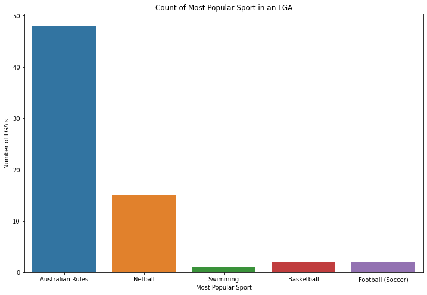

```python
fig = plt.figure(figsize=(12,8))
sns.countplot(data = most_claimed_sport, x = 'Top_Sport')
plt.title('Count of Most Popular Sport in an LGA')
plt.ylabel("Number of LGA's")
plt.xlabel("Most Popular Sport")
plt.show()
```

As to be expected due to the distribution of vouchers claimed by sport, Australian Rules was the most popular sport in 48 LGA's. Netball was the most popular sport in 15 LGA's. The most popular sport was neither Australian Rules or Netball in only 5 LGA's, whose popular sport was either Basketball, Soccer or Swimming.

```python
#add to map table
map_data = pd.merge(map_data,most_claimed_sport,left_on='abbname', right_on='Participant_LGA')
```

```python
#label encode sports
map_data["Top_Sport"] = map_data["Top_Sport"].astype('category')
map_data["Top_Sport_cat"] = map_data["Top_Sport"].cat.codes
```

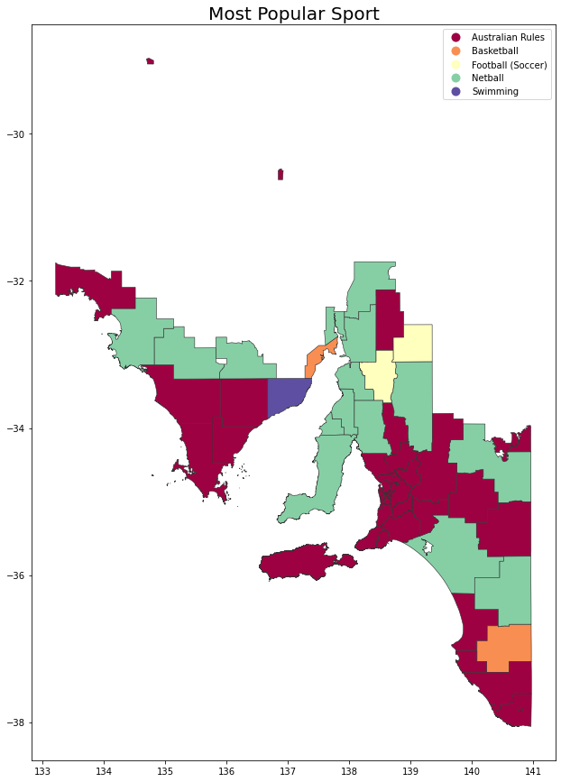

```python
#plotting map using geopandas
map_data.plot(column='Top_Sport', categorical=True, cmap='Spectral',figsize=(15, 15), linewidth=.6, edgecolor='0.2',legend=True)
plt.title('Most Popular Sport',fontsize=20)
plt.show()
```

NOTE: An interactive map was created and the code is available below. The code was not run as it made the file size to large to commit to github. Insights are based off the interactive map.

```python
#plotting the most popular sport by the number of vouchers claimed for each LGA (interactive map)
mL = folium.Map(location=[-34.6, 134.85], zoom_start=6.5, tiles='CartoDB positron', zoom_control=True,scrollWheelZoom=False,dragging=False)
x = folium.Choropleth(
    geo_data=map_data,
    name="choropleth",
    data=map_data,
    columns=["abbname", "Top_Sport_cat"],
    key_on="feature.properties.abbname",
    fill_color="Set1",
    line_color = 'grey',
    line_weight = 2,
    fill_opacity=0.7,
    line_opacity=1,
).add_to(mL)

style_function = lambda x: {'fillColor': '#ffffff',
                            'color':'#000000',
                            'fillOpacity': 0.1,
                            'weight': 0.1}

highlight_function = lambda x: {'fillColor': '#000000',
                                'color':'#000000',
                                'fillOpacity': 0.50,
                                'weight': 0.1}

folium.features.GeoJson(
    map_data, name = 'LGA',
    popup=folium.features.GeoJsonPopup(fields=['abbname', 'Top_Sport']),
    style_function = style_function,
    highlight_function = highlight_function,
    ).add_to(mL)

#removes legend
for key in x._children:
    if key.startswith('color_map'):
        del(x._children[key])
folium.LayerControl().add_to(mL)
mL
```

The map above shows the most popular sport by number of vouchers claimed for each of the LGA's.

Australian rules was the most popular sport within LGA's in and around the capital city of Adelaide as well as across a number of the rural LGA's. Netball was the most popular sport within a number of regional LGA's. Soccer was the most popular sport for the two bordering LGA's of PETERBOROUGH and NORTHERN AREAS located to the North of Adelaide. Swimming was the most popular sport for the costal LGA of FRANKLIN HARBOUR. Basketball was the most popular sport within two LGA's. The LGA of WHYALLA was noted earlier due to the large number of vouchers it had claimed compared to neighbouring LGA's. Interestingly the most popular sport within this LGA was basketball which was only the 5th most popular sport across the state.

```python
#convert vouchers claimed by sport to % of total LGA vouchers claimed
res = sport_x_lga.div(sport_x_lga.sum(axis=1), axis=0)
```

```python
#drop sport if it does not make up at least 10% of total vouchers claimed
for column in res:
    if res[column].sum() < 0.10:
        res.drop(columns = [column], inplace = True)
```

```python
# Only include LGA's within the IQR of number of vouchers claimed
iqr = list(lga_dist.index[(lga_dist['Vouchers_Claimed'] >339) & (lga_dist['Vouchers_Claimed'] <2227)])
res = res[res.index.isin(iqr)]
```

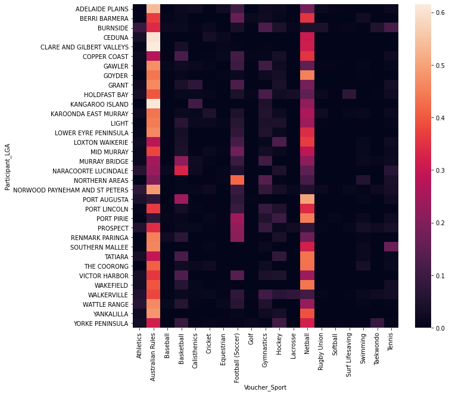

```python
#Generate heatmap
plt.figure(figsize=(10,10))
sns.heatmap(res)
```

While Australian Rules is very popular in nearly all LGA's, it is less popular in PORT AUGUSTA and PORT PERRIE. Popular sports in PORT AUGUSTA include Netball and Basketball. Sports more popular than Australian Rules in PORT PERRIE include Netball, Hockey and Soccer.

## 2.7 Over/Under Representation of Vouchers Claimed

*Are any LGA's over/under represented in their use of vouchers?*

```python
#create per person table
LGA_desc.drop(columns = 'Voucher_Value', inplace=True)
lga_stats = pd.merge(LGA_desc,lga_dist,left_on='Participant_LGA', right_on='unique_values')
lga_stats['Vouchers_PP'] = lga_stats['Vouchers_Claimed']/lga_stats['Population']
lga_stats.head()
```

|  | Participant_LGA | IER | IRSAD | IRSD | Population | Vouchers_Claimed | Vouchers_PP |
| --- | --- | --- | --- | --- | --- | --- | --- |
| 0 | ONKAPARINGA | 996.0 | 975.0 | 993.0 | 159517.0 | 12782 | 0.080129 |
| 1 | ADELAIDE | 874.0 | 1036.0 | 1013.0 | 19606.0 | 302 | 0.015403 |
| 2 | YORKE PENINSULA | 969.0 | 933.0 | 952.0 | 11046.0 | 977 | 0.088448 |
| 3 | CHARLES STURT | 957.0 | 971.0 | 976.0 | 104922.0 | 6897 | 0.065735 |
| 4 | PORT ADELAIDE ENFIELD | 921.0 | 929.0 | 930.0 | 112797.0 | 6384 | 0.056597 |

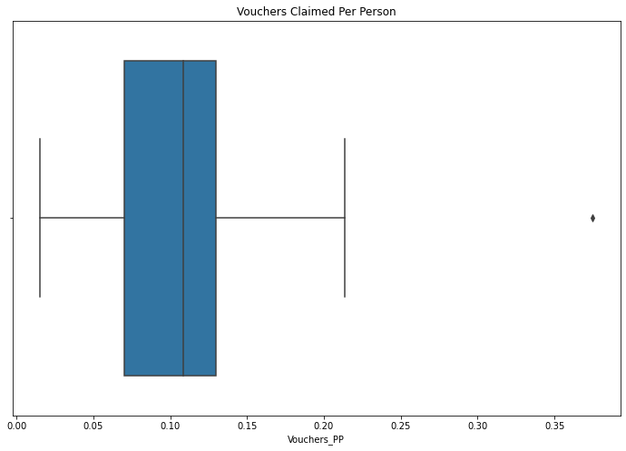

```python
#boxplot of vouchers claimed per person
fig = plt.figure(figsize=(12,8))
sns.boxplot(lga_stats['Vouchers_PP'])
plt.title("Vouchers Claimed Per Person")
plt.show()
```

The average number of vouchers claimed per person in an LGA is 0.1065. A single outlier can be observed with a per person claim rate of 0.3749. It would be reasonable to assume that LGA's with a claim rate below the 25 percentile of 0.07 claims per person are underrepresented. And those LGA's with a claim rate above the 75% of 0.1296 claims per person are overrepresented.

```python
#include pp stats to map data
map_data = pd.merge(
    map_data,
    lga_stats.drop(columns = 'Vouchers_Claimed'),
    left_on='abbname',
    right_on='Participant_LGA')
map_data.drop(columns = ['Participant_LGA'], inplace=True)
```

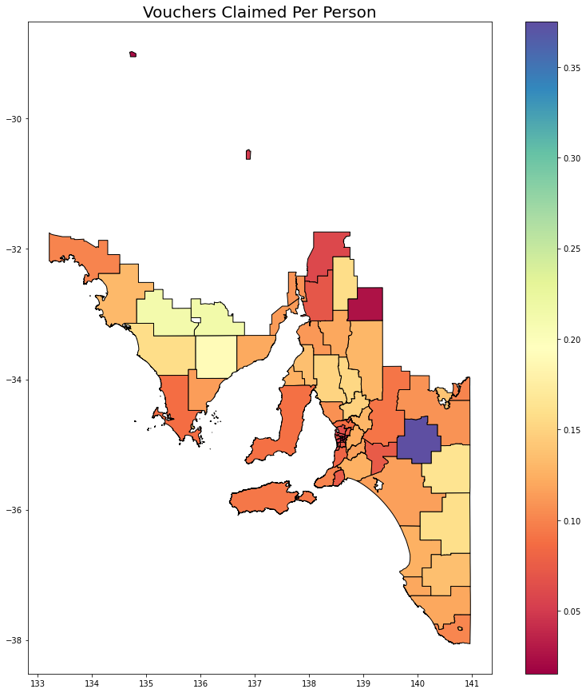

```python
#plotting map using geopandas
map_data.plot(column='Vouchers_PP', cmap='Spectral', edgecolor = 'k', legend = 'True', figsize=(15, 15))
plt.title('Vouchers Claimed Per Person',fontsize=20)
plt.show()
```

NOTE: An interactive map was created and the code is available below. The code was not run as it made the file size to large to commit to github. Insights are based off the interactive map.

```python
#plotting voucher claimed data to interactive map (click on LGA to see Label and number of vouchers claimed)
mP = folium.Map(location=[-34.6, 134.85], zoom_start=6.5, tiles='CartoDB positron', zoom_control=False,scrollWheelZoom=False,dragging=False)
folium.Choropleth(
    geo_data=map_data,
    name="choropleth",
    data=map_data,
    columns=["abbname", "Vouchers_PP"],
    key_on="feature.properties.abbname",
    fill_color="Spectral",
    line_color = 'grey',
    line_weight = 2,
    fill_opacity=0.7,
    line_opacity=1,
    legend_name="Per Person Voucher Claim Rate",
).add_to(mP)

style_function = lambda x: {'fillColor': '#ffffff',
                            'color':'#000000',
                            'fillOpacity': 0.1,
                            'weight': 0.1}

highlight_function = lambda x: {'fillColor': '#000000',
                                'color':'#000000',
                                'fillOpacity': 0.50,
                                'weight': 0.1}

folium.features.GeoJson(
    map_data, name = 'LGA',
    popup=folium.features.GeoJsonPopup(fields=['abbname', 'Vouchers_PP']),
    style_function = style_function,
    highlight_function = highlight_function,
    ).add_to(mP)
folium.LayerControl().add_to(mP)
mP
```

The above map shows the voucher claim rate of each LGA. The KAROONDA EAST MURRAY has the largest claim rate of 0.375 and is a rural LGA located to the east of Adelaide. Most of the rural LGA's appear to be reasonably well represented except for the 3 LGA's located to the north. The LGA's within the city of Adelaide are underrepresented, which may be due to the demographic composition of Adelaide.

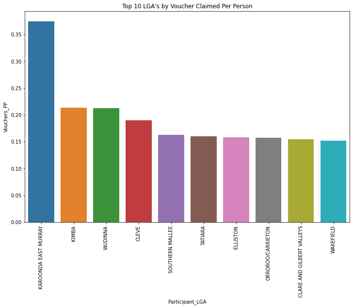

```python
#top ten LGA's by vouchers claimed per person
fig = plt.figure(figsize=(12,8))
lga_stats = lga_stats.sort_values(by='Vouchers_PP', ascending=False)
sns.barplot(x='Participant_LGA', y = 'Vouchers_PP' , data = lga_stats.head(10)).set(title = "Top 10 LGA's by Voucher Claimed Per Person")
plt.xticks(rotation=90)
plt.show()
```

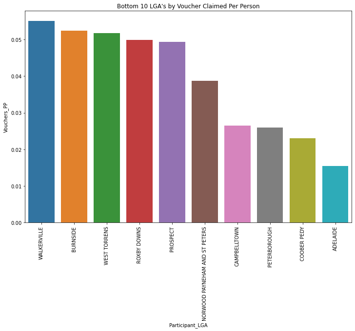

```python
#Bottom ten LGA's by vouchers claimed per person
fig = plt.figure(figsize=(12,8))
sns.barplot(x='Participant_LGA', y = 'Vouchers_PP' , data = lga_stats.tail(10)).set(title = "Bottom 10 LGA's by Voucher Claimed Per Person")
plt.xticks(rotation=90)
plt.show()
```

## 2.8 Relationships between SEIFA measures and voucher use

*Is there a relationship between any of the SEIFA measures and voucher use in an LGA?*

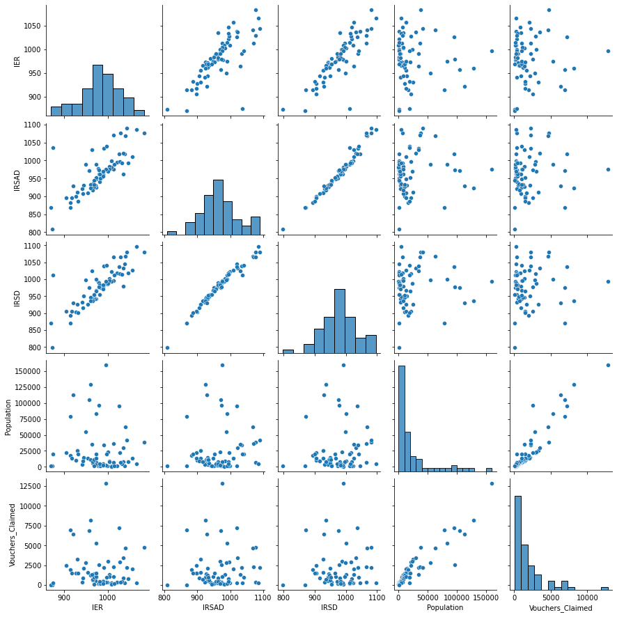

```python
#pair plot to compare relationships between voucher use and SEIFA measures
lga_stats.drop(columns='Vouchers_PP', inplace = True)
sns.pairplot(lga_stats)
```

A number of positive linear relationships exist between a number of the SEIFA measures. With regards to vouchers claimed there is a positive linear relationship between number of vouchers claimed and population. No linear relationship appears to exist between number of vouchers claimed and other SEIFA measures. Strong and moderate positive linear relationships can be observed between SEIFA measures.

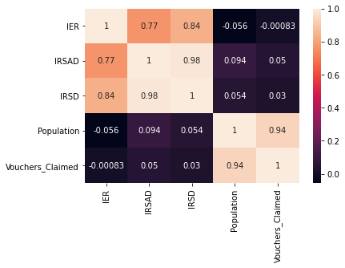

```python
#correlation matrix
sns.heatmap(lga_stats.corr(), annot=True)
```

The correlation matrix shows a strong positive correlation between number of vouchers claimed and population. No correlation (minimal) was observed between SEIFA measures and number of vouchers claimed.

Based on the pairplot and correlation matrix the SEIFA measures could not be used to accurately predict number of vouchers claimed by an LGA.

## 2.9 Challenge - Queensland

*Note: this is an extra task that you might take on to get a better grade for your portfolio. You can get a good pass grade without doing this.*

Queensland has a similar program called [Get Started](https://data.gov.au/dataset/ds-qld-3118838a-d425-48fa-bfc9-bc615ddae44e/details?q=get%20started%20vouchers) and we can retrieve data from their program in a similar format.

The file round1-redeemed_get_started_vouchers.csv contains records of the vouchers issued in Queensland. The date of this data is not included but the program started in 2015 so it is probably from around then.

The data includes the LGA of the individual but the name of the activity is slightly different. To do a comparable analysis you would need to map the activity names onto those from South Australia.

```python
qld_vouchers = pd.read_csv('files/round1-redeemed_get_started_vouchers.csv')
qld_vouchers.head()
```

|  | Application Number | Voucher Number | Child Age (at time of Application) | Gender | Has your child played sport before? | Participation Activity | Club Name | Club Suburb/Town | Club Local Government Area Name | Club State Electoral District Name | Parent Suburb/Town | Total Payment |
| --- | --- | --- | --- | --- | --- | --- | --- | --- | --- | --- | --- | --- |
| 0 | 2000012253 | Q89QDUXP | 10 | NaN | Yes | *Other | Queensland Police-Citizens Youth Welfare Assoc... | Airlie Beach | Whitsunday (R) | Whitsunday | Jubilee Pocket | 60.01 |
| 1 | 2000001727 | 593F6Y41 | 5 | NaN | No | *Other | Guides Queensland | Windsor | Brisbane (C) | Brisbane Central | Leichhardt | 150.00 |
| 2 | 2000013464 | PH2R4RTT | 5 | NaN | No | *Other | Guides Queensland | Windsor | Brisbane (C) | Brisbane Central | Woodridge | 150.00 |
| 3 | 2000009270 | 035SE2H5 | 5 | NaN | Yes | *Other | Guides Queensland | Windsor | Brisbane (C) | Brisbane Central | Yatala | 150.00 |
| 4 | 2000007273 | NP6C4729 | 6 | NaN | No | *Other | Guides Queensland | Windsor | Brisbane (C) | Brisbane Central | Alexandra Hills | 150.00 |

```python
# Join the QLD data with the LGA data as before to get population and SIEFA data integrated
qld_vouchers['LGA'] = qld_vouchers['Club Local Government Area Name'].str.replace(' \([RC]+\)', '').str.upper()
qld_vouchers_scores = qld_vouchers.join(LGA_scores, on='LGA')
qld_vouchers_scores.head()
```

|  | Application Number | Voucher Number | Child Age (at time of Application) | Gender | Has your child played sport before? | Participation Activity | Club Name | Club Suburb/Town | Club Local Government Area Name | Club State Electoral District Name | Parent Suburb/Town | Total Payment | LGA | IEO | IER | IRSAD | IRSD | Population |
| --- | --- | --- | --- | --- | --- | --- | --- | --- | --- | --- | --- | --- | --- | --- | --- | --- | --- | --- |
| 0 | 2000012253 | Q89QDUXP | 10 | NaN | Yes | *Other | Queensland Police-Citizens Youth Welfare Assoc... | Airlie Beach | Whitsunday (R) | Whitsunday | Jubilee Pocket | 60.01 | WHITSUNDAY | 989.0 | 989.0 | 966.0 | 982.0 | 31393.0 |
| 1 | 2000001727 | 593F6Y41 | 5 | NaN | No | *Other | Guides Queensland | Windsor | Brisbane (C) | Brisbane Central | Leichhardt | 150.00 | BRISBANE | 1018.0 | 1018.0 | 1057.0 | 1048.0 | 1042074.0 |
| 2 | 2000013464 | PH2R4RTT | 5 | NaN | No | *Other | Guides Queensland | Windsor | Brisbane (C) | Brisbane Central | Woodridge | 150.00 | BRISBANE | 1018.0 | 1018.0 | 1057.0 | 1048.0 | 1042074.0 |
| 3 | 2000009270 | 035SE2H5 | 5 | NaN | Yes | *Other | Guides Queensland | Windsor | Brisbane (C) | Brisbane Central | Yatala | 150.00 | BRISBANE | 1018.0 | 1018.0 | 1057.0 | 1048.0 | 1042074.0 |
| 4 | 2000007273 | NP6C4729 | 6 | NaN | No | *Other | Guides Queensland | Windsor | Brisbane (C) | Brisbane Central | Alexandra Hills | 150.00 | BRISBANE | 1018.0 | 1018.0 | 1057.0 | 1048.0 | 1042074.0 |

```python
num_sports = len(set(qld_vouchers_scores['Participation Activity']))
print(f'The Number of Sports involved in the program is: {num_sports}')
```

```
The Number of Sports involved in the program is: 66
```

In Queensland Australian Rules is called Australian Football, Pony Club is called Pony Clubs and Bushwalking is called Orienteering.

```python
#renaming sports
qld_vouchers_scores['Participation Activity'].loc[qld_vouchers_scores['Participation Activity']=='Australian Football'] = 'Australian Rules'
qld_vouchers_scores['Participation Activity'].loc[qld_vouchers_scores['Participation Activity']=='Pony Club'] = 'Pony Clubs'
qld_vouchers_scores['Participation Activity'].loc[qld_vouchers_scores['Participation Activity']=='Bushwalking'] = 'Orienteering'
```

```python
#find top 10 sports in QLD
qld_top_sports = pd.DataFrame(qld_vouchers_scores['Participation Activity'].value_counts()).reset_index()
qld_top_sports.rename(columns={'index': 'Sport', 'Participation Activity': 'Vouchers_Claimed'}, inplace = True)
qld_top_sports.head(10)
```

|  | Sport | Vouchers_Claimed |
| --- | --- | --- |
| 0 | Rugby League | 2782 |
| 1 | Football (Soccer) | 2074 |
| 2 | Netball | 1263 |
| 3 | Australian Rules | 548 |
| 4 | Gymnastics | 539 |
| 5 | Basketball | 376 |
| 6 | Rugby Union | 342 |
| 7 | Hockey | 271 |
| 8 | Swimming | 157 |
| 9 | Pony Clubs | 148 |

```python
print(f'The total number of vouchers claimed in Queensland is: {qld_vouchers_scores.shape[0]}')
```

```
The total number of vouchers claimed in Queensland is: 9507
```

```python
#add percentage of vouchers claimed in QLD by sport
qld_top_sports['QLD %'] = round((qld_top_sports['Vouchers_Claimed']/qld_vouchers_scores.shape[0])*100,2)
qld_top_sports.drop(columns = 'Vouchers_Claimed', inplace = True)
qld_top_sports.head()
```

|  | Sport | QLD % |
| --- | --- | --- |
| 0 | Rugby League | 29.26 |
| 1 | Football (Soccer) | 21.82 |
| 2 | Netball | 13.28 |
| 3 | Australian Rules | 5.76 |
| 4 | Gymnastics | 5.67 |

```python
#Top 10 sports in SA
sa_top_sports = pd.DataFrame(sa_vouchers_scores['Voucher_Sport'].value_counts()).reset_index()
sa_top_sports.rename(columns={'index': 'Sport', 'Participation Activity': 'Vouchers_Claimed'}, inplace = True)
sa_top_sports.head(10)
```

|  | Sport | Voucher_Sport |
| --- | --- | --- |
| 0 | Australian Rules | 47051 |
| 1 | Netball | 23938 |
| 2 | Football (Soccer) | 15662 |
| 3 | Gymnastics | 9754 |
| 4 | Basketball | 5967 |
| 5 | Athletics | 4501 |
| 6 | Tennis | 3730 |
| 7 | Hockey | 3012 |
| 8 | Calisthenics | 2506 |
| 9 | Cricket | 1853 |

```python
#add percentage of vouchers claimed in QLD by sport
sa_top_sports['SA %'] = round((sa_top_sports['Voucher_Sport']/sa_vouchers_scores.shape[0])*100,2)
sa_top_sports.drop(columns = 'Voucher_Sport', inplace = True)
sa_top_sports.head()
```

|  | Sport | SA % |
| --- | --- | --- |
| 0 | Australian Rules | 37.08 |
| 1 | Netball | 18.86 |
| 2 | Football (Soccer) | 12.34 |
| 3 | Gymnastics | 7.69 |
| 4 | Basketball | 4.70 |

```python
#join tables
state_comp = pd.merge(qld_top_sports, sa_top_sports, on='Sport', how='inner')
state_comp.sort_values(by = 'QLD %',ascending=False, inplace=True)
state_comp.head()
```

|  | Sport | QLD % | SA % |
| --- | --- | --- | --- |
| 0 | Rugby League | 29.26 | 0.21 |
| 1 | Football (Soccer) | 21.82 | 12.34 |
| 2 | Netball | 13.28 | 18.86 |
| 3 | Australian Rules | 5.76 | 37.08 |
| 4 | Gymnastics | 5.67 | 7.69 |

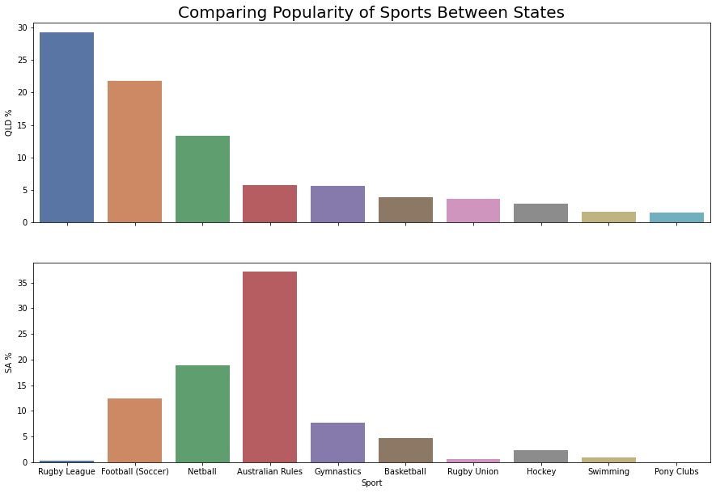

```python
f, (ax1, ax2) = plt.subplots(2, 1, figsize=(15, 10), sharex=True)
sns.barplot(data = state_comp.head(10), x='Sport', y = 'QLD %', palette="deep", ax=ax1)
sns.barplot(data = state_comp.head(10), x='Sport', y = 'SA %', palette="deep", ax=ax2)
ax1.set_xlabel('')
ax1.set_title('Comparing Popularity of Sports Between States', size = 20)
plt.show()
```

By percentage of total vouchers claimed rugby league was the most popular in Queensland, making up a little less then 30% of all vouchers. In South Australia Rugby League made up a very small percentage of vouchers claimed. Australian Rules was the 4th most popular sport in Queensland and the most popular sport in South Australia. Netball, Gymnastics and Basketball made up similar percentages of vouchers claimed in both states.